# RUV normalization of iPSC samples

Kushal K Dey, Joyce H Siao

July 27, 2015

The iPSC data was found to have individual effects and batch effects. The individual effect (there were 3 individuals) was the strongest, and both the reads/molecules data seemed to be clustering as per individuals. Initially it seemed there is no batch effect. But when we looked closely at one specific individual, we found that the batch effect seems to be there. So batch effect seems to be nested within the individual. RUV assumes the batch effects as additive and may not be a great tool to normalize when the two effects (individual and batch effect here) are such that one effect is nested within another.

So, the aim of this script is two-fold

1. To compare the density of the ERCC genes across the individuals and batches and see if the ERCC genes indeed change across the batches for one particular individual. This should not ideally be the case.
2. To see if RUV normalization is performed within an individual, if the normalized samples show the batch effect or not.

```r
suppressMessages(suppressWarnings(library("edgeR")))
suppressMessages(suppressWarnings(library("ggplot2")))
theme_set(theme_bw(base_size = 16))
suppressMessages(suppressWarnings(library("RUVSeq")))
suppressMessages(suppressWarnings(library("preprocessCore")))
suppressMessages(suppressWarnings(library("affy")))
suppressMessages(suppressWarnings(library(data.table)))
suppressMessages(suppressWarnings(library(reshape2)))
suppressMessages(suppressWarnings(library(testit)))
suppressMessages(suppressWarnings(library(qtlcharts)))
source('functions.R')
```

Reading the reads and the molecules data.

```r
anno <- read.table("../data/annotation.txt", header = TRUE,
                   stringsAsFactors = FALSE)

reads <- data.frame(fread("../data/reads.txt", header = FALSE,
                    stringsAsFactors = FALSE),row.names=1);
```

```
##
Read 0.0% of 20420 rows
Read 49.0% of 20420 rows
Read 97.9% of 20420 rows
Read 20420 rows and 874 (of 874) columns from 0.041 GB file in 00:00:08
```

```r
molecules <- data.frame(fread("../data/molecules.txt", header = TRUE,
                    stringsAsFactors = FALSE),row.names=1);
```

Next we read the ERCC information table

```r
ercc <- read.table("../data/ercc-info.txt", header = TRUE, sep = "\t",
                   stringsAsFactors = FALSE)
colnames(ercc) <- c("num", "id", "subgroup", "conc_mix1", "conc_mix2",
                    "expected_fc", "log2_mix1_mix2")
head(ercc)
```

```
##   num         id subgroup conc_mix1  conc_mix2 expected_fc log2_mix1_mix2
## 1   1 ERCC-00130        A 30000.000 7500.00000           4              2
## 2   2 ERCC-00004        A  7500.000 1875.00000           4              2
## 3   3 ERCC-00136        A  1875.000  468.75000           4              2
## 4   4 ERCC-00108        A   937.500  234.37500           4              2
## 5   5 ERCC-00116        A   468.750  117.18750           4              2
## 6   6 ERCC-00092        A   234.375   58.59375           4              2
```

Next we filter out the single cells in the molecules data, we remove the cells in batch 2 for individual 1. Finally remove the genes that have 0 counts across all the cells.

```r
stopifnot(nrow(ercc) == 92)
quality_single_cells <- scan("../data/quality-single-cells.txt",
                             what = "character")

## just filtering cells that meet the QC check

molecules_single <- molecules[, colnames(molecules) %in% quality_single_cells]
anno_single <- anno[anno$sample_id %in% quality_single_cells, ]
stopifnot(ncol(molecules_single) == nrow(anno_single),
          colnames(molecules_single) == anno_single$sample_id)

## remove indivual 1 and batch 2 samples

molecules_single <- molecules_single[, !(anno_single$individual == 19098 & anno_single$batch == 2)]
anno_single <- anno_single[!(anno_single$individual == 19098 & anno_single$batch == 2), ]
stopifnot(ncol(molecules_single) == nrow(anno_single))

## remove zero count genes

expressed_single <- rowSums(molecules_single) > 0
molecules_single <- molecules_single[expressed_single, ]
dim(molecules_single)
```

```
## [1] 17478   563
```

```r
## remove genes that are overexpressed

overexpressed_genes <- rownames(molecules_single)[apply(molecules_single, 1,
                                                        function(x) any(x >= 1024))]
molecules_single <- molecules_single[!(rownames(molecules_single) %in% overexpressed_genes), ]

molecules_single_collision <- -1024 * log(1 - molecules_single / 1024)
```

We obtain the CPM data from the counts data

```r
## calculating the cpm

molecules_single_cpm <- cpm(molecules_single_collision, log = TRUE)
```

Detect which rows of the matrix correspond to ERCCs and which to actual genes.

```r
ercc_rows_single <- grep("ERCC", rownames(molecules_single))
gene_rows_single <- grep("ERCC", rownames(molecules_single), invert = TRUE)

ercc <- ercc[order(ercc$id), ]
# Also remove spike-ins with no counts
ercc_single <- ercc[ercc$id %in% rownames(molecules_single), ]
stopifnot(rownames(molecules_single[ercc_rows_single, ]) == ercc_single$id)
```

```r
ercc_rows <- rownames(molecules_single)[ercc_rows_single];
ercc_rows_single_mod <- ercc_rows_single[ercc$id %in% rownames(molecules_single)];
ercc_rows_single_mod <- ercc_rows_single_mod[!is.na(ercc_rows_single_mod)];

molecules_single_ercc_cpm <- molecules_single_cpm[ercc_rows_single_mod,];
molecules_single_ercc <- molecules_single[ercc_rows_single_mod,];

numzeros <- apply(molecules_single_ercc,1, function(x) length(x[x==0]))

molecules_single_ercc <- molecules_single_ercc[as.numeric(which(numzeros <=50)),];

molecules_single_ercc_cpm <- molecules_single_ercc_cpm[as.numeric(which(numzeros <=50)),];

ercc_final_lab <- ercc_rows_single_mod[as.numeric(which(numzeros <=50))];
```

We plot the signal or the log cpm values of the ERCC genes selected from above across the single cells to see how the behavioral pattern of these genes across the different single cells looks liek. It seems they are pretty uniformly varying across all the single cells.

```r
individual_id = unlist(lapply(strsplit(colnames(molecules_single_ercc_cpm), "\\."), function(x) x[1]));
batch_id = unlist(lapply(strsplit(colnames(molecules_single_ercc_cpm), "\\."), function(x) x[2]));

ercc_indiv <-  lapply(1:length(unique(individual_id)),function(n) molecules_single_ercc[,which(individual_id==unique(individual_id)[n])])

batch_id_indiv <- lapply(1:length(unique(individual_id)),function(n) batch_id[which(individual_id==unique(individual_id)[n])]);

iplotCurves(log(ercc_indiv[[1]]+0.5,base=2))
```

```
## Set screen size to height=700 x width=1000
```

[interactive chart not shown]

```r
iplotCurves(log(ercc_indiv[[2]]+0.5,base=2))
```

[interactive chart not shown]

```r
iplotCurves(log(ercc_indiv[[3]]+0.5,base=2))
```

[interactive chart not shown]

```r
#first_indiv_ercc_plot <-  melt(ercc_indiv[[1]]);
#p <- ggplot(aes(x=value, colour=Var1), data=first_indiv_ercc_plot)
#p + geom_density()
```

It seems that the ERCC expression is not determined by the batch effects.

We next obtain the cell cycle phases.

```r
cell_cycle_genes <- read.table("../data/cellcyclegenes.txt", header = TRUE, sep="\t")

## create 5 lists of 5 phases (de-level and then remove "")
cell_cycle_genes_list <- lapply(1:5,function(x){
  temp <- as.character(cell_cycle_genes[,x])
  temp[temp!=""]
})

ans <-
sapply(cell_cycle_genes_list,function(xx){
  #### create table of each phase
  molecules_single_phase <- molecules_single[rownames(molecules_single) %in% unlist(xx) ,]
  #### add average expression of all genes in the phase
  combined_matrix <- rbind(molecules_single_phase,average=apply(molecules_single_phase,2,mean))
  #### use transpose to compute cor matrix
  cor_matrix <- cor(t(combined_matrix))
  #### take the numbers
  cor_vector <- cor_matrix[,dim(cor_matrix)[1]]
  #### restrict to correlation >= 0.3
  molecules_single_phase_restricted <- molecules_single_phase[rownames(molecules_single_phase) %in% names(cor_vector[cor_vector >= 0.3]),]
  #### apply normalization to reads
  norm_factors_single <- calcNormFactors(molecules_single_phase_restricted, method = "TMM")
  molecules_single_cpm <- cpm(molecules_single_phase_restricted, log = TRUE,
                            lib.size = colSums(molecules_single) * norm_factors_single)
  #### output the phase specific scores (mean of normalized expression levels in the phase)
  apply(molecules_single_cpm,2,mean)

})

#head(ans)

#### normalization function
flexible_normalization <- function(data_in,by_row=TRUE){
  if(by_row){
    row_mean <- apply(data_in,1,mean)
    row_sd   <- apply(data_in,1,sd)
    output <- data_in
    for(i in 1:dim(data_in)[1]){
      output[i,] <- (data_in[i,] - row_mean[i])/row_sd[i]
    }
  }
  #### if by column
  if(!by_row){
    col_mean <- apply(data_in,2,mean)
    col_sd   <- apply(data_in,2,sd)
    output <- data_in
    for(i in 1:dim(data_in)[2]){
      output[,i] <- (data_in[,i] - col_mean[i])/col_sd[i]
    }
  }
  output
}

#### apply the normalization function
## first normalized for each phase
ans_normed <- flexible_normalization(ans,by_row=FALSE)
## then normalized of each cell
ans_normed_normed <- flexible_normalization(ans_normed,by_row=TRUE)

#head(ans_normed_normed)

cell_phase_mat <- apply(ans_normed_normed,1,function(x) colnames(cell_cycle_genes)[which.max(x)])
cell_phase <- as.vector(as.matrix(data.frame(cell_phase_mat)))
```

First we do PC plots before RUV normalization and we check whether the batch effects show up or not in the ERCC genes. Ideally it should not show up.

## PC plots ERCC genes before RUV

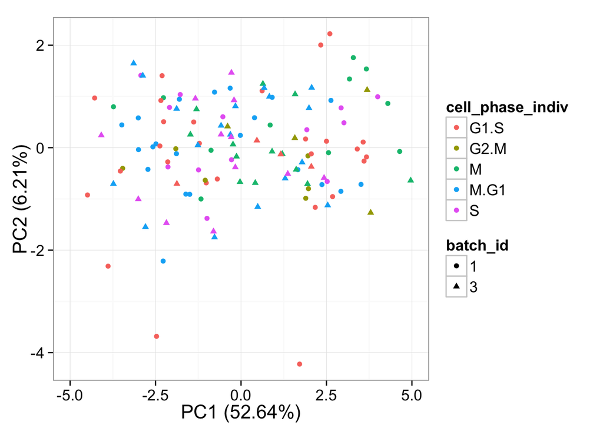

```r
#molecules_single_ercc_cpm <- molecules_single_cpm[ercc_rows_single_mod,];
individual_id_full = unlist(lapply(strsplit(colnames(molecules_single_ercc_cpm), "\\."), function(x) x[1]));

ercc_indiv_cpm <-  lapply(1:length(unique(individual_id_full)),function(n) molecules_single_ercc_cpm[,which(individual_id_full==unique(individual_id_full)[n])])

metadata_ercc <- lapply(1:3, function(n)
                             {
                                anno_indiv <- colnames(ercc_indiv_cpm[[n]]);
                                indiv_id = unlist(lapply(strsplit(colnames(ercc_indiv_cpm[[n]]), "\\."), function(x) x[1]));
                                batch_id = unlist(lapply(strsplit(colnames(ercc_indiv_cpm[[n]]), "\\."), function(x) x[2]));
                                well_id = unlist(lapply(strsplit(colnames(ercc_indiv_cpm[[n]]), "\\."), function(x) x[3]));
                                cell_phase_indiv =cell_phase[match(colnames(ercc_indiv_cpm[[n]]),colnames(molecules_single_cpm))];
                                out <- as.data.frame(cbind(indiv_id,batch_id,well_id,cell_phase_indiv,anno_indiv));
                                return(out)
                              });



pca_single_raw <- run_pca(ercc_indiv_cpm[[1]])
plot_pca(pca_single_raw$PCs, explained = pca_single_raw$explained,scale=5,
         xaxs=TRUE,metadata = metadata_ercc[[1]], color ="cell_phase_indiv",
         shape = "batch_id", factors = c("cell_phase_indiv", "batch_id"))
```

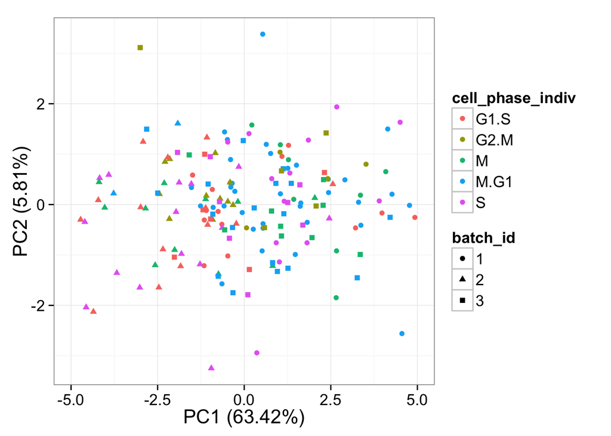

```r
pca_single_raw <- run_pca(ercc_indiv_cpm[[2]])
plot_pca(pca_single_raw$PCs, explained = pca_single_raw$explained,scale=5,
         xaxs=TRUE,metadata = metadata_ercc[[2]], color ="cell_phase_indiv",
         shape = "batch_id", factors = c("cell_phase_indiv", "batch_id"))
```

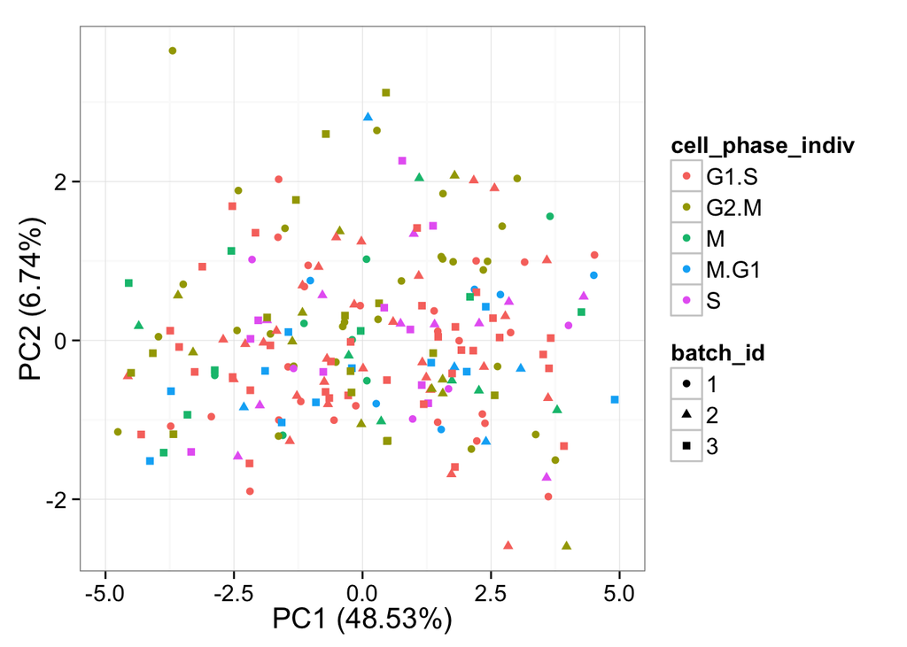

```r
pca_single_raw <- run_pca(ercc_indiv_cpm[[3]])
plot_pca(pca_single_raw$PCs, explained = pca_single_raw$explained,scale=5,
         xaxs=TRUE, metadata = metadata_ercc[[3]], color="cell_phase_indiv",
         shape = "batch_id", factors = c("cell_phase_indiv", "batch_id"))
```

Now we consider the PC plots of the non ERCC genes before RUV normalization. This should show batch effects if the batch effects indeed exist.

## PC plots non ERCC genes before RUV

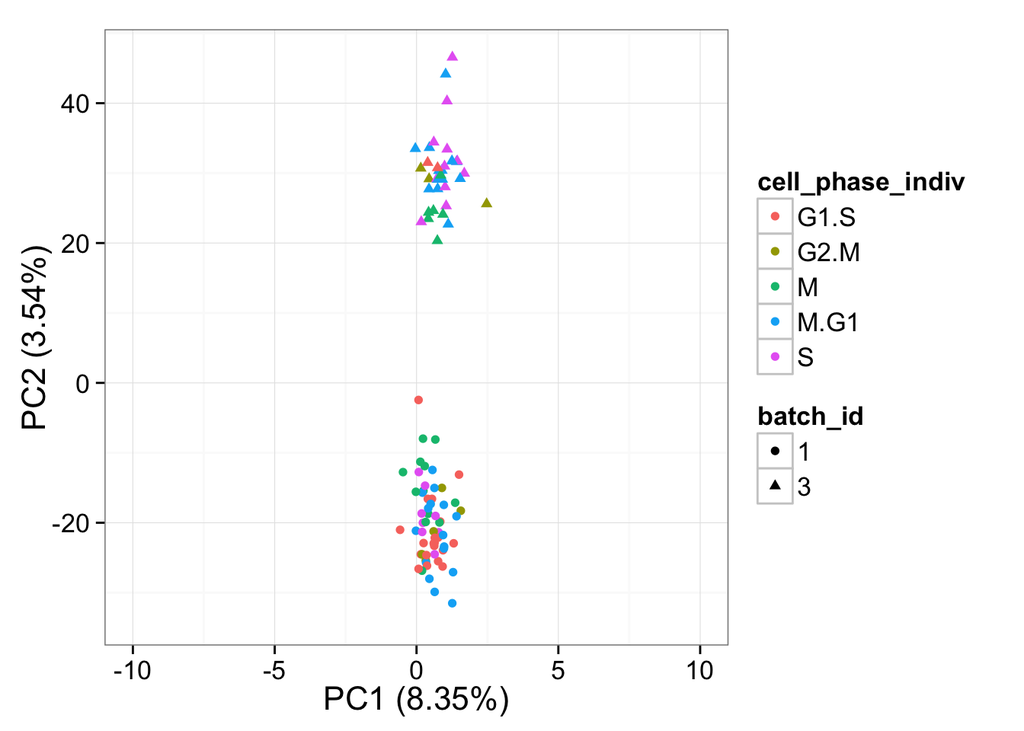

```r
molecules_single_genes_cpm <- molecules_single_cpm[-ercc_rows_single,];
individual_id_full = unlist(lapply(strsplit(colnames(molecules_single_genes_cpm), "\\."), function(x) x[1]));

genes_indiv_cpm <-  lapply(1:length(unique(individual_id_full)),function(n) molecules_single_genes_cpm[,which(individual_id_full==unique(individual_id_full)[n])])

metadata_genes <- lapply(1:3, function(n)
                              {
                                  anno_indiv <- colnames(genes_indiv_cpm[[n]]);
                                  indiv_id =unlist(lapply(strsplit(colnames(genes_indiv_cpm[[n]]), "\\."),
                                                          function(x) x[1]));
                                  batch_id = unlist(lapply(strsplit(colnames(genes_indiv_cpm[[n]]), "\\."),
                                                           function(x) x[2]));
                                  well_id = unlist(lapply(strsplit(colnames(genes_indiv_cpm[[n]]), "\\."),
                                                          function(x) x[3]));
                                  cell_phase_indiv =cell_phase[match(colnames(genes_indiv_cpm[[n]]),
                                                                     colnames(molecules_single_cpm))];
                                  out <- as.data.frame(cbind(indiv_id,batch_id,well_id,
                                                                  cell_phase_indiv,anno_indiv));
                                  return(out)
                                });


pca_single_raw <- run_pca(genes_indiv_cpm[[1]])
plot_pca(pca_single_raw$PCs, explained = pca_single_raw$explained,scale=10,
         xaxs=TRUE,metadata = metadata_genes[[1]], color="cell_phase_indiv",
         shape = "batch_id", factors = c("cell_phase_indiv", "batch_id"))
```

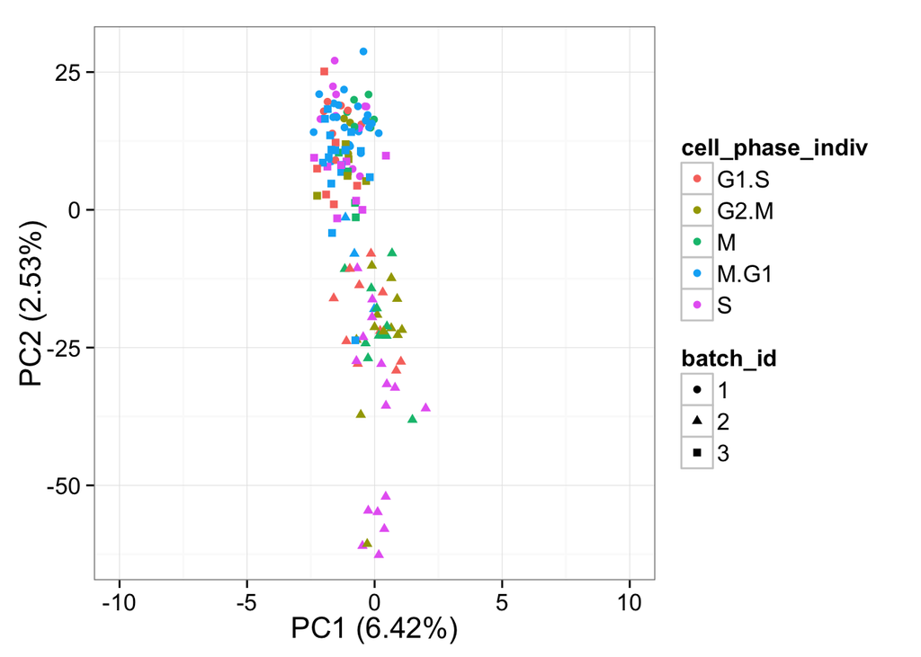

```r
pca_single_raw <- run_pca(genes_indiv_cpm[[2]])
plot_pca(pca_single_raw$PCs, explained = pca_single_raw$explained,scale=10,
         xaxs=TRUE,metadata = metadata_genes[[2]], color="cell_phase_indiv",
         shape = "batch_id", factors = c("cell_phase_indiv", "batch_id"))
```

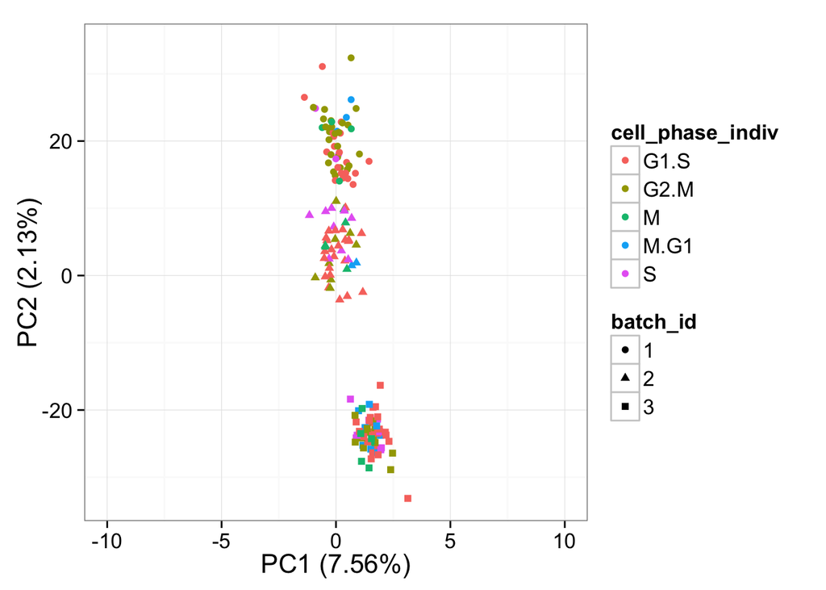

```r
pca_single_raw <- run_pca(genes_indiv_cpm[[3]])
plot_pca(pca_single_raw$PCs, explained = pca_single_raw$explained,scale=10,
         xaxs=TRUE,metadata = metadata_genes[[3]], color="cell_phase_indiv",
         shape = "batch_id", factors = c("cell_phase_indiv", "batch_id"))
```

As you can check from the above figures, the batch effects for the non ERCCC genes are clearly visible.

Now we consider the ERCC genes after RUV with k=1. Since the ERCC genes without RUV showed no batch effect after filtration, it does not seem likely the next plots would be any different.

## ERCC genes RUV -k=1

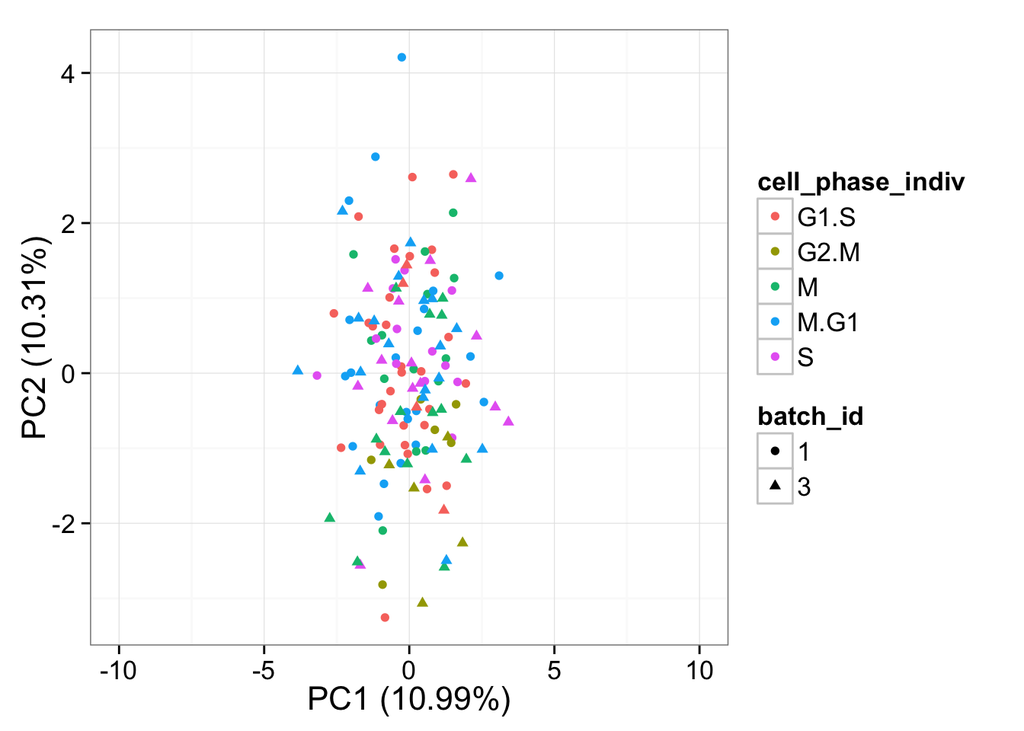

```r
#molecules_single_ercc <- molecules_single[ercc_rows_single,];
individual_id_full = unlist(lapply(strsplit(colnames(molecules_single_ercc), "\\."), function(x) x[1]));

ercc_indiv <-  lapply(1:length(unique(individual_id_full)),function(n) molecules_single_ercc[,which(individual_id_full==unique(individual_id_full)[n])])
single_ruv_object_k1 <- RUVg(x = as.matrix(ercc_indiv[[1]]),  k = 1)
single_ruv_k1 <- single_ruv_object_k1$normalizedCounts
single_ruv_cpm_k1 <- cpm(single_ruv_k1, log = TRUE,
                      lib.size = calcNormFactors(single_ruv_k1) * colSums(single_ruv_k1))

pca_single_ruv_k1 <- run_pca(single_ruv_cpm_k1)
suppressMessages(suppressWarnings(plot_pca(pca_single_ruv_k1$PCs, explained = pca_single_ruv_k1$explained,xaxs=TRUE,scale=10,
         metadata = metadata_ercc[[1]], color = "cell_phase_indiv",
         shape = "batch_id", factors = c("cell_phase_indiv", "batch_id"))))
```

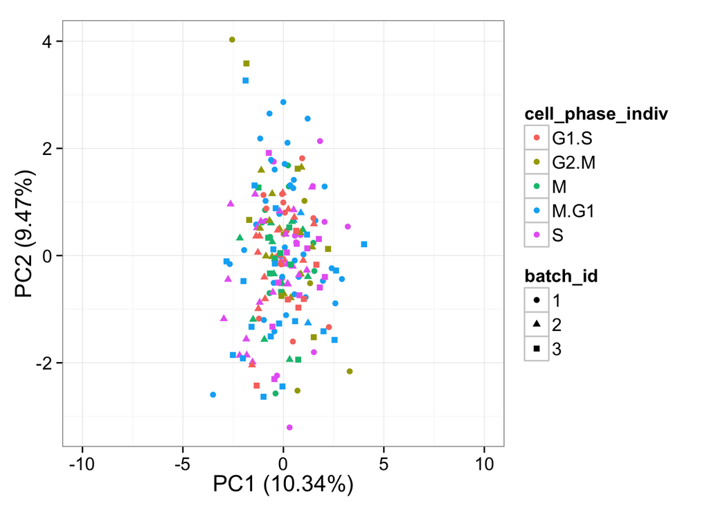

```r
single_ruv_object_k1 <- RUVg(x = as.matrix(ercc_indiv[[2]]),  k = 1)
single_ruv_k1 <- single_ruv_object_k1$normalizedCounts
single_ruv_cpm_k1 <- cpm(single_ruv_k1, log = TRUE,
                      lib.size = calcNormFactors(single_ruv_k1) * colSums(single_ruv_k1))

pca_single_ruv_k1 <- run_pca(single_ruv_cpm_k1)
suppressMessages(suppressWarnings(plot_pca(pca_single_ruv_k1$PCs, explained = pca_single_ruv_k1$explained,xaxs=TRUE,scale=10,
         metadata = metadata_ercc[[2]], color = "cell_phase_indiv",
         shape = "batch_id", factors = c("cell_phase_indiv", "batch_id"))))
```

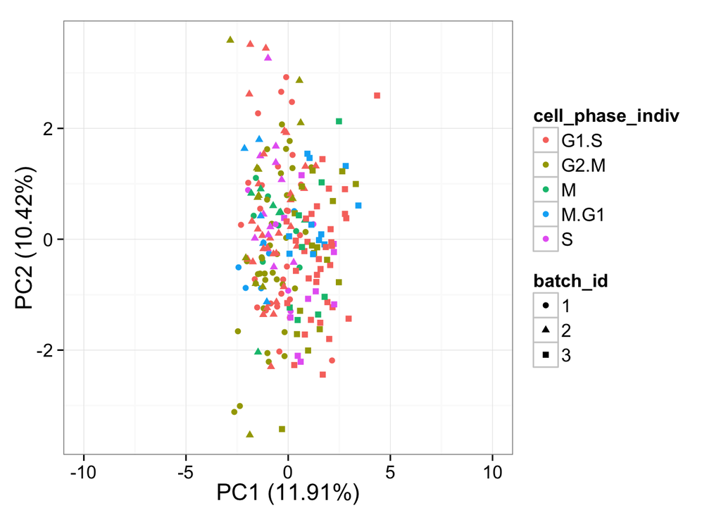

```r
single_ruv_object_k1 <- RUVg(x = as.matrix(ercc_indiv[[3]]),  k = 1)
single_ruv_k1 <- single_ruv_object_k1$normalizedCounts
single_ruv_cpm_k1 <- cpm(single_ruv_k1, log = TRUE,
                      lib.size = calcNormFactors(single_ruv_k1) * colSums(single_ruv_k1))

pca_single_ruv_k1 <- run_pca(single_ruv_cpm_k1)
suppressMessages(suppressWarnings(plot_pca(pca_single_ruv_k1$PCs, explained = pca_single_ruv_k1$explained,xaxs=TRUE,scale=10,
         metadata = metadata_ercc[[3]], color = "cell_phase_indiv",
         shape = "batch_id", factors = c("cell_phase_indiv", "batch_id"))))
```

Finally we perform RUV on the non ERCC genes using ERCC as controls. The ERCC genes should take care of the batch effects and that the non ERCC genes after RUV normalization should not show batch effects. But it seems, though the batch effects are not as strong as the ones without RUV, still the batch effects are kind of retained.

## RUVg on non-ERCC genes using ERCC as controls

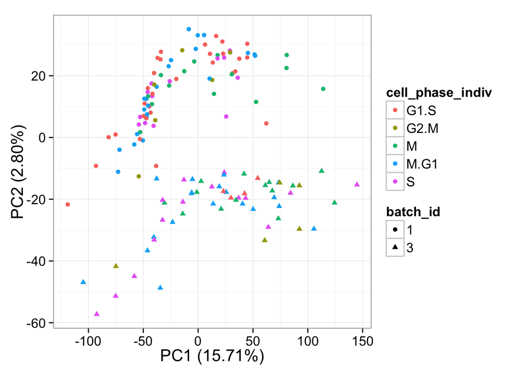

```r
individual_id_full = unlist(lapply(strsplit(colnames(molecules_single), "\\."), function(x) x[1]));

molecules_single_indiv <- lapply(1:length(unique(individual_id_full)),function(n) molecules_single[,which(individual_id_full==unique(individual_id_full)[n])])

single_ruv_object_k1 <- RUVg(x = as.matrix(molecules_single_indiv[[1]]), cIdx = ercc_rows_single_mod[which(numzeros<=50)], k = 1)
single_ruv_k1 <- single_ruv_object_k1$normalizedCounts
single_ruv_cpm_k1 <- cpm(single_ruv_k1, log = TRUE,
                      lib.size = calcNormFactors(single_ruv_k1) * colSums(single_ruv_k1))

pca_single_ruv_k1 <- run_pca(single_ruv_cpm_k1)
suppressMessages(suppressWarnings(plot_pca(pca_single_ruv_k1$PCs, explained = pca_single_ruv_k1$explained, xaxs=FALSE,
         metadata = metadata_genes[[1]], color = "cell_phase_indiv",
         shape = "batch_id", factors = c("cell_phase_indiv", "batch_id"))))
```

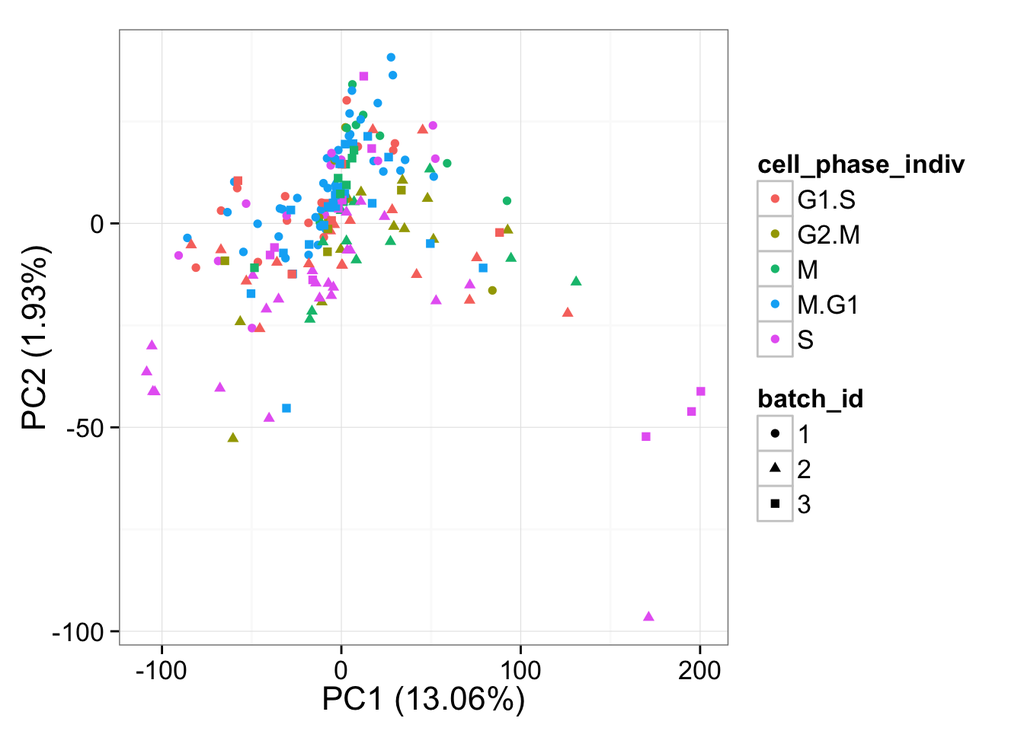

```r
single_ruv_object_k1 <- RUVg(x = as.matrix(molecules_single_indiv[[2]]), cIdx = ercc_rows_single_mod[which(numzeros<=50)], k = 1)
single_ruv_k1 <- single_ruv_object_k1$normalizedCounts
single_ruv_cpm_k1 <- cpm(single_ruv_k1, log = TRUE,
                      lib.size = calcNormFactors(single_ruv_k1) * colSums(single_ruv_k1))

pca_single_ruv_k1 <- run_pca(single_ruv_cpm_k1)
suppressMessages(suppressWarnings(plot_pca(pca_single_ruv_k1$PCs, explained = pca_single_ruv_k1$explained, xaxs=FALSE,
         metadata = metadata_genes[[2]], color = "cell_phase_indiv",
         shape = "batch_id", factors = c("cell_phase_indiv", "batch_id"))))
```

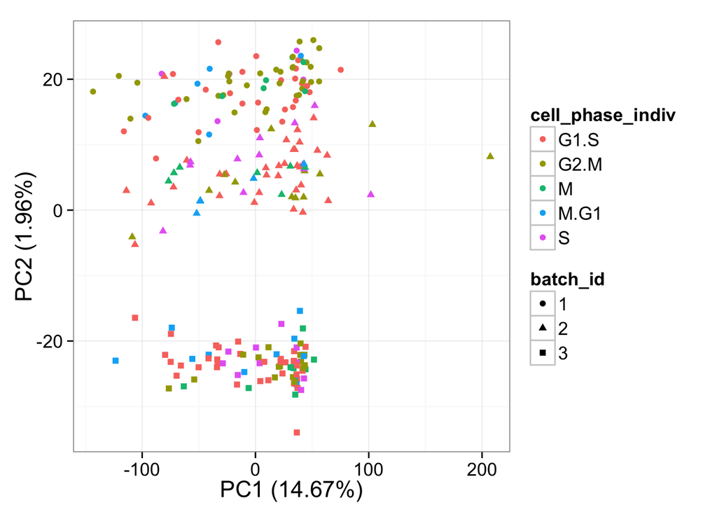

```r
single_ruv_object_k1 <- RUVg(x = as.matrix(molecules_single_indiv[[3]]), cIdx = ercc_rows_single_mod[which(numzeros<=50)], k = 1)
single_ruv_k1 <- single_ruv_object_k1$normalizedCounts
single_ruv_cpm_k1 <- cpm(single_ruv_k1, log = TRUE,
                      lib.size = calcNormFactors(single_ruv_k1) * colSums(single_ruv_k1))

pca_single_ruv_k1 <- run_pca(single_ruv_cpm_k1)
suppressMessages(suppressWarnings(plot_pca(pca_single_ruv_k1$PCs, explained = pca_single_ruv_k1$explained, xaxs=FALSE,
         metadata = metadata_genes[[3]], color = "cell_phase_indiv",
         shape = "batch_id", factors = c("cell_phase_indiv", "batch_id"))))
```